# Yet Another Poll Aggregator

Alex Pavlakis

# yapa

Yapa is a simple poll aggregator designed to simulate state-level results in US presidential elections by combining data from state level polls with prior information from previous presidential election results.

# Model

The number of respondents in each poll $p$ in state $s$ who support each candidate $c$ ($y_{s(p), c(p)}$) is sampled from a binomial distribution of the total respondents in than poll $n_p$ with rate paramter specific to the candidate and the state $\theta_{s(p), c(p)}$. That rate parameter is drawn from a prior distribution with candidate-state specific mean $\alpha_{c, s}$ and state specific variance $t_s$. The sum of proportions for each candidate must equal one.

$$\begin{align}
y_{s(p), c(p)} &\sim Binomial(n_p, \theta_{s(p), c(p)}) \\
\theta_{s, c} &\sim Normal(\alpha_{s, c}, \tau_{s}) \\
\sum_c \theta_s &= 1
\end{align}$$

In this model, we use the results of the previous presidential election in each state as prior $\alpha$.

## Assumptions

1. polls are unbiased *on average* (unrealistic).
2. There is no time-trend in the true underlying support for each candidate in each state, just different realizations from a distribution (unrealistic).
3. state general election results are unlikely to deviate more than 20 percentage points from their results in the previous general election.

# Results

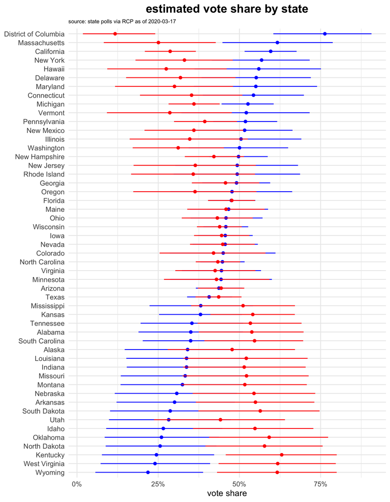

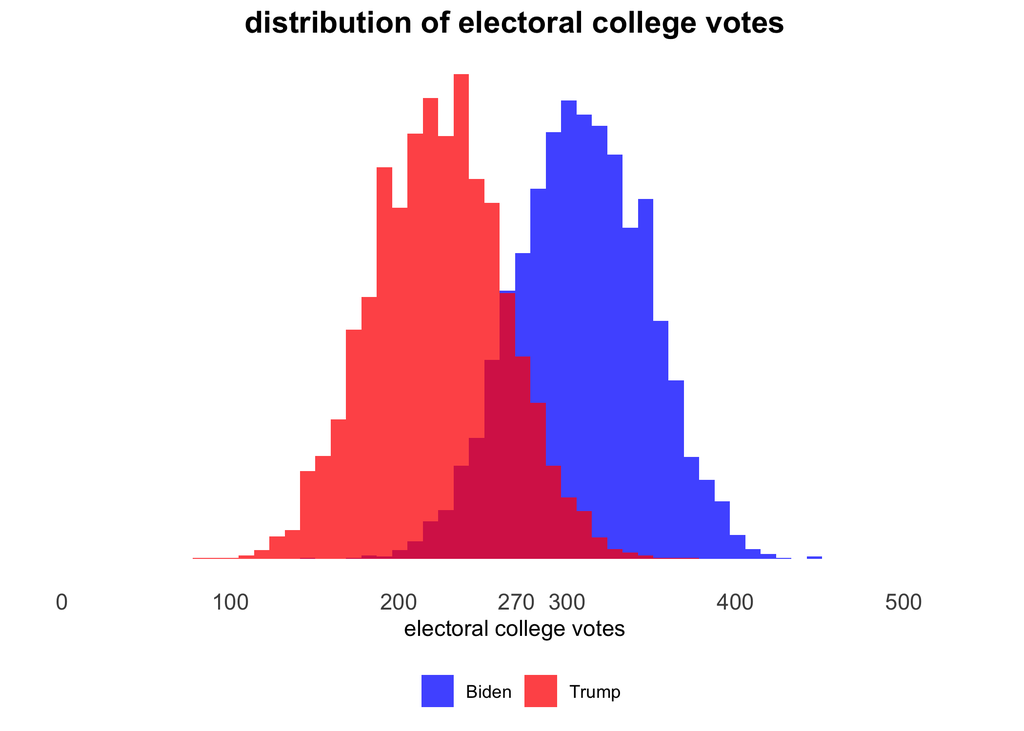